# R Notebook

Deliverable 1: Linear Regression to Predict MPG

Use the library() function to load the dplyr package.

```r
library(dplyr)
library(tidyverse)
```

Import and read in the MechaCar_mpg.csv file as a dataframe.

```r
MechaCar_mpg_df <- read.csv('MechaCar_mpg.csv',stringsAsFactors = F) #read in dataset
head(MechaCar_mpg_df)
```

|  | vehicle_length | vehicle_weight | spoiler_angle | ground_clearance | AWD | mpg |
| --- | --- | --- | --- | --- | --- | --- |
| 1 | 14.69710 | 6407.946 | 48.78998 | 14.64098 | 1 | 49.04918 |
| 2 | 12.53421 | 5182.081 | 90.00000 | 14.36668 | 1 | 36.76606 |
| 3 | 20.00000 | 8337.981 | 78.63232 | 12.25371 | 0 | 80.00000 |
| 4 | 13.42849 | 9419.671 | 55.93903 | 12.98936 | 1 | 18.94149 |
| 5 | 15.44998 | 3772.667 | 26.12816 | 15.10396 | 1 | 63.82457 |
| 6 | 14.45357 | 7286.595 | 30.58568 | 13.10695 | 0 | 48.54268 |

Type the following code into the R console to look at the lm() documentation in the Help pane:

```r
?lm()
```

Perform linear regression using the lm() function. In the lm() function, pass in all six variables (i.e., columns), and add the dataframe you created in Step 4 as the data parameter.

To create a linear regression model, our R statement would be as follows:

```r
lm(formula = mpg ~ vehicle_length + vehicle_weight + spoiler_angle + ground_clearance + AWD, data = MechaCar_mpg_df) #create linear model
```

```
Call:
lm(formula = mpg ~ vehicle_length + vehicle_weight + spoiler_angle +
    ground_clearance + AWD, data = MechaCar_mpg_df)

Coefficients:
     (Intercept)    vehicle_length    vehicle_weight
      -1.040e+02         6.267e+00         1.245e-03
   spoiler_angle  ground_clearance               AWD
       6.877e-02         3.546e+00        -3.411e+00
```

```r
summary(lm(formula = mpg ~ vehicle_length + vehicle_weight + spoiler_angle + ground_clearance + AWD, data = MechaCar_mpg_df)) #generate summary statistics
```

```
Call:
lm(formula = mpg ~ vehicle_length + vehicle_weight + spoiler_angle +
    ground_clearance + AWD, data = MechaCar_mpg_df)

Residuals:
     Min       1Q   Median       3Q      Max
-19.4701  -4.4994  -0.0692   5.4433  18.5849

Coefficients:
                   Estimate Std. Error t value Pr(>|t|)
(Intercept)      -1.040e+02  1.585e+01  -6.559 5.08e-08 ***
vehicle_length    6.267e+00  6.553e-01   9.563 2.60e-12 ***
vehicle_weight    1.245e-03  6.890e-04   1.807   0.0776 .
spoiler_angle     6.877e-02  6.653e-02   1.034   0.3069
ground_clearance  3.546e+00  5.412e-01   6.551 5.21e-08 ***
AWD              -3.411e+00  2.535e+00  -1.346   0.1852
---
Signif. codes:  0 ‘***’ 0.001 ‘**’ 0.01 ‘*’ 0.05 ‘.’ 0.1 ‘ ’ 1

Residual standard error: 8.774 on 44 degrees of freedom
Multiple R-squared:  0.7149,    Adjusted R-squared:  0.6825
F-statistic: 22.07 on 5 and 44 DF,  p-value: 5.35e-11
```

Deliverable 2: Create Visualizations for the Trip Analysis

Download the Suspension_Coil.csv file, and place it in the active directory for your R session.

```r
coil_table <- read.csv('Suspension_Coil.csv',check.names = F,stringsAsFactors = F)
coil_table
```

| VehicleID | Manufacturing_Lot | PSI |
| --- | --- | --- |
| V40858 | Lot1 | 1499 |
| V40607 | Lot1 | 1500 |
| V31443 | Lot1 | 1500 |
| V6004 | Lot1 | 1500 |
| V7000 | Lot1 | 1501 |
| V17344 | Lot1 | 1501 |
| V37049 | Lot1 | 1500 |
| V9048 | Lot1 | 1499 |
| V40947 | Lot1 | 1501 |
| V4682 | Lot1 | 1500 |

[output cut: 140 more lines]

Write an RScript that creates a total_summary dataframe using the summarize() function to get the mean, median, variance, and standard deviation of the suspension coil’s PSI column.

```r
total_summary <- coil_table %>% summarize(Mean=mean(PSI),Median=median(PSI),Variance=var(PSI), SD=sd(PSI), .groups = 'keep') #Create a total summary
```

Write an RScript that creates a lot_summary dataframe using the group_by() and the summarize() functions to group each manufacturing lot by the mean, median, variance, and standard deviation of the suspension coil’s PSI column.

```r
lot_summary <- coil_table %>% group_by(Manufacturing_Lot) %>% summarize(Mean=mean(PSI),Median=median(PSI),Variance=var(PSI), SD=sd(PSI), .groups = 'keep') #Create a total summary
```

Deliverable 3: T-Tests on Suspension Coils

Wite an RScript using the t.test() function to determine if the PSI across all manufacturing lots is statistically different from the population mean of 1,500 pounds per square inch.

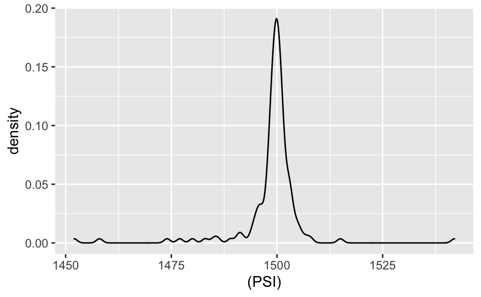

```r
plt<- ggplot(coil_table,aes(x=(PSI)))
plt + geom_density()
```

```r
t.test((coil_table$PSI),mu=1500) #compare sample versus population means
```

```
    One Sample t-test

data:  (coil_table$PSI)
t = -1.8931, df = 149, p-value = 0.06028
alternative hypothesis: true mean is not equal to 1500
95 percent confidence interval:
 1497.507 1500.053
sample estimates:
mean of x
  1498.78
```

```r
t.test(subset(coil_table,Manufacturing_Lot=="Lot1")$PSI,mu=1500) #compare sample versus population means
```

```
    One Sample t-test

data:  subset(coil_table, Manufacturing_Lot == "Lot1")$PSI
t = 0, df = 49, p-value = 1
alternative hypothesis: true mean is not equal to 1500
95 percent confidence interval:
 1499.719 1500.281
sample estimates:
mean of x
     1500
```

```r
t.test(subset(coil_table,Manufacturing_Lot=="Lot2")$PSI,mu=1500) #compare sample versus population means
```

```
    One Sample t-test

data:  subset(coil_table, Manufacturing_Lot == "Lot2")$PSI
t = 0.51745, df = 49, p-value = 0.6072
alternative hypothesis: true mean is not equal to 1500
95 percent confidence interval:
 1499.423 1500.977
sample estimates:
mean of x
   1500.2
```

```r
t.test(subset(coil_table,Manufacturing_Lot=="Lot3")$PSI,mu=1500) #compare sample versus population means
```

```
    One Sample t-test

data:  subset(coil_table, Manufacturing_Lot == "Lot3")$PSI
t = -2.0916, df = 49, p-value = 0.04168
alternative hypothesis: true mean is not equal to 1500
95 percent confidence interval:
 1492.431 1499.849
sample estimates:
mean of x
  1496.14
```